# Notebook

#### Plot some support_vectors, for some dimensions

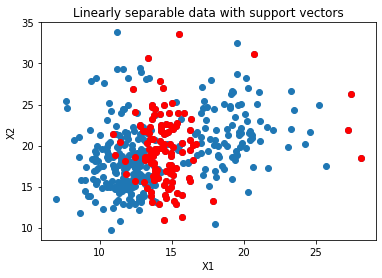

```python
import matplotlib.pyplot as plt

# Get support vectors themselves
support_vectors = svm.support_vectors_

# Visualize support vectors
plt.scatter(X_train[:,0], X_train[:,1])
plt.scatter(support_vectors[:,0], support_vectors[:,1], color='red')
plt.title('Linearly separable data with support vectors')
plt.xlabel('X1')
plt.ylabel('X2')
plt.show()
```

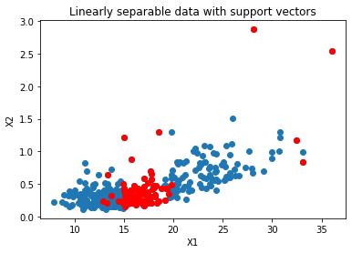

```python
import matplotlib.pyplot as plt
# Get support vectors themselves
support_vectors = svm.support_vectors_

# Visualize support vectors
plt.scatter(X_train[:,20], X_train[:,10])
plt.scatter(support_vectors[:,20], support_vectors[:,10], color='red')
plt.title('Linearly separable data with support vectors')
plt.xlabel('X1')
plt.ylabel('X2')
plt.show()
```

### Normalizing Data

We cam improve performance by normalizing data  
SVMs are very sensitive to the scale, and data in our case is not scaled (i.e Normalized) So let's try to see how each feature currently looks like or where exactly the minimum or the maximum of each feature is.

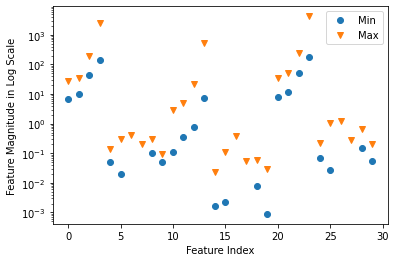

```python
import matplotlib.pyplot as plt
%matplotlib inline

plt.plot(X_train.min(axis=0), 'o', label='Min')
plt.plot(X_train.max(axis=0), 'v', label='Max')
plt.xlabel('Feature Index')
plt.ylabel('Feature Magnitude in Log Scale')
plt.yscale('log')
plt.legend(loc='upper right')
```

There are large gaps between the minimum and maximum of each value and also a difference in orders of magnitude in between features.  
This is a factor that leads to the low performance of our SVM.

**Let's Normalize data !**  
We could simply use scalers that are built-in scikit-learn like the standard scalar or the min/max scalar and so on that are available in the pre-processing module.  
We are going to do it by hand to kind of better understand what data scaling means.  
Try to bring the values of each feature of each sample whitin a certain range like 0 to 1.

```python
# The minimum value of each feature
min_train = X_train.min(axis=0)

# The range of each feature by substracting the minimum from the maximum.
range_train = X_train.max(axis=0) - min_train

# Substract the minimum for each feature and divide by the range to bring data between 0 & 1
X_train_scaled = (X_train - min_train) / range_train

print('Minimum per feature\n{}'.format(X_train_scaled.min(axis=0)))
print('Maximum per feature\n{}'.format(X_train_scaled.max(axis=0)))
```

```
Minimum per feature
[0. 0. 0. 0. 0. 0. 0. 0. 0. 0. 0. 0. 0. 0. 0. 0. 0. 0. 0. 0. 0. 0. 0. 0.
 0. 0. 0. 0. 0. 0.]
Maximum per feature
[1. 1. 1. 1. 1. 1. 1. 1. 1. 1. 1. 1. 1. 1. 1. 1. 1. 1. 1. 1. 1. 1. 1. 1.
 1. 1. 1. 1. 1. 1.]
```

#### Normalize test set

```python
X_test_scaled = (X_test - min_train)/range_train
```

[output not shown]

```python
svm = SVC()
svm.fit(X_train_scaled, y_train)
```

```python
print('The accuracy on the training subset: {:.3f}'.format(svm.score(X_train_scaled, y_train)))
print('The accuracy on the test subset: {:.3f}'.format(svm.score(X_test_scaled, y_test)))
```

```
The accuracy on the training subset: 0.984
The accuracy on the test subset: 0.972
```

It is much better but we are in a situation of under-fitting.

### Hyper Parameter Tuning

What hyper parameter should we try adjusting first to improve the performance of the algorithm ?  
Let's try with C ang Gamma which control the complexity of the model.

Intuitively :

- Gamma defines how far the influence of a single training example reaches, with low values meaning ‘far’ and high values meaning ‘close’.

The gamma parameters can be seen as the inverse of the radius of influence of samples selected by the model as support vectors. It determines the distance a single data sample exerts influence on.

- C is The regularization parameter (lambda) serves as a degree of importance that is given to miss-classifications

The C parameter trades off misclassification of training examples against simplicity of the decision surface. A low C makes the decision surface smooth, while a high C aims at classifying all training examples correctly by giving the model freedom to select more samples as support vectors

```python
svm = SVC(C=50)
svm.fit(X_train_scaled, y_train)

print('The accuracy on the training subset: {:.3f}'.format(svm.score(X_train_scaled, y_train)))
print('The accuracy on the test subset: {:.3f}'.format(svm.score(X_test_scaled, y_test)))
```

```
The accuracy on the training subset: 0.995
The accuracy on the test subset: 0.979
```

Performance is very good so no need to try with Gamma.

**Improvements :** As always, fine tuning can happen.

### Advantages and Disadvantages of SVMs

#### Stronger points:

- Versatility which means they can do well on a varied range of datasets.
- Can build complex decision boundaries on low-dimensional data.
- Can work well on high-dimensional data with relatively small sample size.
- etc...

#### Weaker points:

- Don't perform well on high-dimensional data with many samples (i.e. > 100k).
- Preprocessing may be required and this implies knowledge and understanding of hyper-parameters.
- Harder to inspect and visualize.
- etc.

#### Alternatives:

- Decision Trees and Random Forests (require less/no preprocessing of data, easier to understand, inspect, and visualize).

#### Good practices:

- Data scaling.
- Other pre-processing.
- Choosing an appropriate kernel.
- Tuning hyper-parameters: C, gamma, etc.